# Challenge 1 Solution

Reading in the first sheet from the Active Duty Marital Data.

Sean Conway  
2021-12-28

```r
library(dplyr)
library(readxl)
library(tidyr)
library(stringr)
file_path <- "../data/ActiveDuty_MaritalStatus.xls"
```

## Before we get started…

This solution makes frequent use of the “pipe”, the `%>%` operator. Introduced in the `magrittr` package (but now commonly associated with `dplyr`, which it comes preloaded in), the pipe allows the user to pass the results of operations to further lines of code.

For example, below we work with the dataframe `mtcars`. We first use the pipe to pass the dataframe downstream. Then, we select the columns `mpg` and `wt`, passing a dataframe with **only** these two columns to the next line of code, which filters the data to only include rows where `mpg`>=15.

```r
mtcars <- as_tibble(mtcars)
mtcars %>%
  select(mpg, wt) %>%
  filter(mpg >= 15)
```

```
# A tibble: 27 × 2
     mpg    wt
   <dbl> <dbl>
 1  21    2.62
 2  21    2.88
 3  22.8  2.32
 4  21.4  3.22
 5  18.7  3.44
 6  18.1  3.46
 7  24.4  3.19
 8  22.8  3.15
 9  19.2  3.44
10  17.8  3.44
# … with 17 more rows
```

For more info on the pipe, watch the video on piping, read the chapter on piping in R4DS, or visit https://magrittr.tidyverse.org/.

## The data

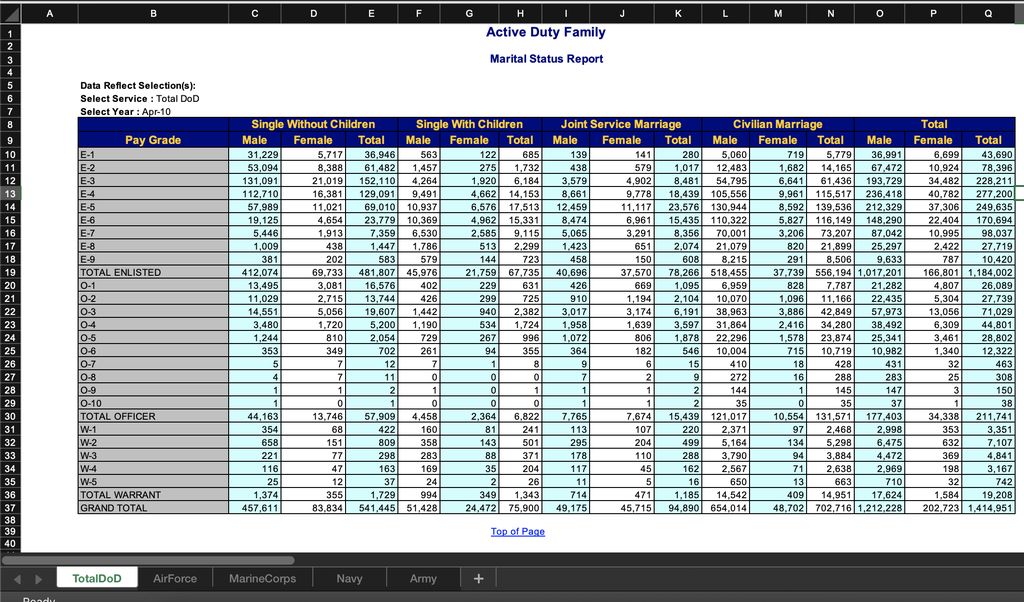

## Reading in the data - First Excel Sheet

While eventually we will want to read in all the sheets at once, we will start out by reading in the first Excel Sheet, *TotalDoD* (see above).

We will use the `read_excel()` function from the `readxl` package.

First, we’re going to manually specify the names of our columns. This involves doing a bit hard coding (reading in messy data is the only time hard coding is recommended!).

```r
col_names_dod <- c("pay_grade",
                   "single_withoutchildren_male",
                    "single_withoutchildren_female",
                    "single_withoutchildren_total",
                    "single_withchildren_male",
                    "single_withchildren_female",
                    "single_withchildren_total",
                    "married_jointservice_male",
                    "married_jointservice_female",
                    "married_jointservice_total",
                    "married_civilian_female",
                    "married_civilian_male",
                    "married_civilian_total",
                    "married_male_total",
                    "married_female_total",
                    "married_total_total")
```

Note that we named these columns so they can be adequately separated later on.

```r
file_path
```

```
[1] "../data/ActiveDuty_MaritalStatus.xls"
```

```r
marital_dod_1 <- read_excel(path=file_path,
                      sheet = 1,
                      range = "B10:Q37",
                      col_names = col_names_dod) %>%
  filter(!str_detect(pay_grade, "total"))#regex("total",ignore_case = TRUE),negate = T))
marital_dod_1
```

```
# A tibble: 28 × 16
   pay_grade      single_withoutch… single_withoutch… single_withoutc…
   <chr>                      <dbl>             <dbl>            <dbl>
 1 E-1                        31229              5717            36946
 2 E-2                        53094              8388            61482
 3 E-3                       131091             21019           152110
 4 E-4                       112710             16381           129091
 5 E-5                        57989             11021            69010
 6 E-6                        19125              4654            23779
 7 E-7                         5446              1913             7359
 8 E-8                         1009               438             1447
 9 E-9                          381               202              583
10 TOTAL ENLISTED            412074             69733           481807
# … with 18 more rows, and 12 more variables:
#   single_withchildren_male <dbl>, single_withchildren_female <dbl>,
#   single_withchildren_total <dbl>, married_jointservice_male <dbl>,
#   married_jointservice_female <dbl>,
#   married_jointservice_total <dbl>, married_civilian_female <dbl>,
#   married_civilian_male <dbl>, married_civilian_total <dbl>,
#   married_male_total <dbl>, married_female_total <dbl>, …
```

We’ve read in the data!

This `tibble` looks okay, but there’s still much work to be done. First, we need to remove any of the columns that contain the word `"total"`. We don’t need these aggregated totals, as they will only muddle the data (plus we can calculate them ourselves if needed).

```r
marital_dod_2 <- marital_dod_1 %>%
  select(c(pay_grade,!contains("total")))
marital_dod_2
```

```
# A tibble: 28 × 9
   pay_grade      single_withoutch… single_withoutch… single_withchil…
   <chr>                      <dbl>             <dbl>            <dbl>
 1 E-1                        31229              5717              563
 2 E-2                        53094              8388             1457
 3 E-3                       131091             21019             4264
 4 E-4                       112710             16381             9491
 5 E-5                        57989             11021            10937
 6 E-6                        19125              4654            10369
 7 E-7                         5446              1913             6530
 8 E-8                         1009               438             1786
 9 E-9                          381               202              579
10 TOTAL ENLISTED            412074             69733            45976
# … with 18 more rows, and 5 more variables:
#   single_withchildren_female <dbl>,
#   married_jointservice_male <dbl>,
#   married_jointservice_female <dbl>, married_civilian_female <dbl>,
#   married_civilian_male <dbl>
```

Next, we’ll use `pivot_longer()` to combine the column names (except for `pay_grade`) into a single column, `status`. We do this because the variable `status` is currently spread across columns (it is **wide**). We want our data to be tidy - where each row is a single observation.

We specify `cols` as every column **except** `pay_grade` with `!contains(pay_grade)`. We also specify that the column names will be moved to `status` and the column values will be moved to `count`.

```r
marital_dod_3 <- marital_dod_2 %>%
  pivot_longer(cols = !contains("pay_grade"),
               names_to = "status", values_to = "count")
marital_dod_3
```

```
# A tibble: 224 × 3
   pay_grade status                        count
   <chr>     <chr>                         <dbl>
 1 E-1       single_withoutchildren_male   31229
 2 E-1       single_withoutchildren_female  5717
 3 E-1       single_withchildren_male        563
 4 E-1       single_withchildren_female      122
 5 E-1       married_jointservice_male       139
 6 E-1       married_jointservice_female     141
 7 E-1       married_civilian_female        5060
 8 E-1       married_civilian_male           719
 9 E-2       single_withoutchildren_male   53094
10 E-2       single_withoutchildren_female  8388
# … with 214 more rows
```

Our data is now tidy! Now we have just a bit more to do. We should use `separate()` to separate `pay_grade` into two columns (`enlisted` and `pay_grade`), as well as separate `status` into three columns (`relationship`, `family_status`, and `gender`).

```r
marital_dod_tidy <- marital_dod_3 %>%
  separate(col=pay_grade, into=c("enlisted","pay_grade"),
           sep="-") %>%
  separate(col=status, into = c("relationship", "family_status","gender"),
           sep = "_")
marital_dod_tidy
```

```
# A tibble: 224 × 6
   enlisted pay_grade relationship family_status   gender count
   <chr>    <chr>     <chr>        <chr>           <chr>  <dbl>
 1 E        1         single       withoutchildren male   31229
 2 E        1         single       withoutchildren female  5717
 3 E        1         single       withchildren    male     563
 4 E        1         single       withchildren    female   122
 5 E        1         married      jointservice    male     139
 6 E        1         married      jointservice    female   141
 7 E        1         married      civilian        female  5060
 8 E        1         married      civilian        male     719
 9 E        2         single       withoutchildren male   53094
10 E        2         single       withoutchildren female  8388
# … with 214 more rows
```